# Figures

## Figure 6: Feature importance from the best model

```r
# Feature Importance
ftr_imp <- read_csv('../../data/tabular/mod/results/best_model/southern_rockies_feature_imps_n55.csv',
                    show_col_types = FALSE)
glimpse(ftr_imp)
```

```
Rows: 10
Columns: 20
$ `system:index` <dbl> 0, 1, 2, 3, 4, 5, 6, 7, 8, 9
$ B2_autumn      <dbl> 49.49731, 53.55798, 46.15995, 44.59732, 36.44691, 52.99102, 49.53374, 53.95200, 50.03963, 45.…
$ B2_summer      <dbl> 34.97310, 32.51703, 37.61583, 39.28662, 31.10338, 33.16864, 30.08473, 33.45479, 37.49951, 37.…
$ B3_autumn      <dbl> 165.1867, 157.1493, 168.6397, 162.4648, 149.4557, 168.8254, 161.2280, 162.8126, 170.3982, 157…
$ B4_autumn      <dbl> 89.04790, 102.29013, 99.24388, 96.15822, 88.75827, 93.63894, 89.72539, 104.08191, 98.86185, 1…
$ B4_summer      <dbl> 72.03866, 84.54776, 67.78854, 75.62744, 65.89027, 80.50073, 75.79995, 77.82927, 76.71519, 77.…
$ B5_summer      <dbl> 58.24769, 64.08761, 58.65716, 70.13235, 49.87718, 68.41857, 61.11606, 62.80698, 63.17702, 56.…
$ CIRE_autumn    <dbl> 57.83576, 58.81169, 64.52829, 52.95184, 53.56839, 61.44669, 50.77975, 62.17084, 63.96603, 61.…
$ CIRE_summer    <dbl> 188.3868, 190.1987, 159.6398, 185.3497, 194.2375, 198.4452, 181.9208, 211.1488, 163.8799, 195…
$ MNDWI_autumn   <dbl> 356.2320, 337.3275, 330.8980, 316.3036, 316.3465, 353.9160, 324.2431, 353.9166, 337.8683, 316…
$ MNDWI_summer   <dbl> 42.57642, 40.28980, 43.35349, 38.25414, 38.65055, 49.04463, 37.95904, 42.87194, 41.04543, 39.…
$ SLAVI_autumn   <dbl> 29.03284, 31.82708, 35.25218, 30.28867, 26.53197, 35.65043, 25.52154, 31.37167, 30.51408, 30.…
$ SLAVI_summer   <dbl> 151.3940, 149.6327, 132.2234, 135.1090, 159.6722, 168.1524, 162.8332, 171.8494, 144.0258, 151…
$ VH_summer_ent  <dbl> 4.398385, 5.996275, 4.397207, 3.379485, 5.188208, 5.741732, 6.728794, 6.930599, 7.557105, 6.2…
$ VH_winter_ent  <dbl> 4.592535, 6.320210, 5.227573, 5.173139, 5.419760, 6.514255, 8.699771, 10.378239, 6.127086, 7.…
$ VV_summer      <dbl> 127.0105, 159.4653, 147.7406, 142.7680, 142.0232, 180.8220, 149.5889, 176.8713, 160.5565, 161…
$ VV_winter      <dbl> 53.30679, 51.75154, 54.96236, 58.44277, 55.25150, 67.25097, 56.83036, 62.59225, 57.43706, 65.…
$ elevation      <dbl> 282.0402, 276.5765, 268.8157, 251.2940, 272.3188, 301.4409, 266.4146, 280.5173, 305.6660, 272…
$ seed           <dbl> 995, 822, 523, 102, 121, 433, 590, 151, 858, 506
$ .geo           <chr> "{\"type\":\"MultiPoint\",\"coordinates\":[]}", "{\"type\":\"MultiPoint\",\"coordinates\":[]}…
```

```r
# Tidy the data frame
df.imp <- ftr_imp %>%
  select(-c(.geo,`system:index`)) %>%
  rename(model = seed) %>%
  mutate(model = as.factor(model))

# Pivot longer
df.imp.p <- df.imp %>%
  pivot_longer(cols = -model) %>%
  rename(importance = value,
         band = name) %>%
  mutate(season = if_else(str_detect(band,"_autumn"), "Autumn S2", "Summer S2"),
         season = if_else(str_detect(band,"_winter"), "Winter S1", season),
         season = if_else(str_detect(band,"VV_summer"), "Summer S1", season),
         season = if_else(str_detect(band,"VH_summer"), "Summer S1", season))
glimpse(df.imp.p)
```

```
Rows: 170
Columns: 4
$ model      <fct> 995, 995, 995, 995, 995, 995, 995, 995, 995, 995, 995, 995, 995, 995, 995, 995, 995, 822, 822, 82…
$ band       <chr> "B2_autumn", "B2_summer", "B3_autumn", "B4_autumn", "B4_summer", "B5_summer", "CIRE_autumn", "CIR…
$ importance <dbl> 49.497311, 34.973098, 165.186734, 89.047904, 72.038658, 58.247693, 57.835765, 188.386846, 356.232…
$ season     <chr> "Autumn S2", "Summer S2", "Autumn S2", "Autumn S2", "Summer S2", "Summer S2", "Autumn S2", "Summe…
```

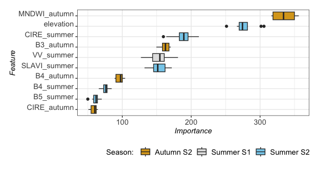

```r
# Grab the top 20 over all model runs
top <- df.imp.p %>%
  group_by(band) %>%
  summarize(median = median(importance)) %>%
  ungroup()
top <- head(arrange(top,desc(median)), n = 10)

# Color palette

cols <- c(
  "Summer S2" = "#87CEEB",
  "Autumn S2" = "#DAA520",
  "Winter S1" = "gray29",
  "Summer S1" = "gray89"
)

# Boxplot

# %>% filter(band %in% top$band)
f6 <- ggplot(data=df.imp.p %>% filter(band %in% top$band),
              aes(x=reorder(band,importance), fill=season)) +
  geom_boxplot(aes(y=importance), position = position_dodge(0.5)) +
  scale_fill_manual(values = cols,
                    labels = c("Autumn S2","Summer S1","Summer S2","Winter S1")) +
  coord_flip() +
  theme_bw(11) +
  theme(axis.text.x = element_text(size=11),
        axis.text.y = element_text(angle = 0, vjust=0, size=11),
        axis.title = element_text(size=11,face="italic"),
        legend.position = "bottom",
        legend.justification = c(1.2,0.5), # Left-aligns the legends
        legend.text = element_text(size=11),
        text = element_text(family = "Arial"),
        plot.margin=unit(c(0.5,0.5,0.5,0.5),"cm")) +
  labs(x="Feature", y="Importance", fill="Season: ")
f6
```

```r
ggsave(f6, file = "../../figures/Figure6_FeatureImportance_top10.png",
       dpi=300, bg="white") # adjust dpi accordingly
```

Clean up!

```r
rm(list = ls.str(mode = 'numeric'))
rm(accmeas,accmeas.best,accmeas.mn,accmeas.s,df.imp,
   df.imp.p,f4,f4a,f4b,f6,ftr_imp,top,cols,arr4,cleaned,
   df,f5b,final_model,ft,opt_thresh,scenarios,scenarios_,testData)
gc()
```

```
           used  (Mb) gc trigger  (Mb) limit (Mb) max used  (Mb)
Ncells  3815449 203.8    5673305 303.0         NA  5673305 303.0
Vcells 43611970 332.8   82892856 632.5      16384 74919126 571.6
```

# Spatial Agreement and Landscape Patch Dynamics

## Table 4: Accuracy of the reference datasets based on test data

```r
ref_acc <- read_csv('../../data/tabular/mod/results/best_model/southern_rockies_ref_accmeas.csv',
                    show_col_types = F)
head(ref_acc)
```

| accuracy | f1_score | precision | recall | reference | metric |
| --- | --- | --- | --- | --- | --- |
| 0.9600314 | 0.8561859 | 0.8168439 | 0.8995093 | lfevt | Predicted |
| 0.9618448 | 0.8657969 | 0.8094890 | 0.9305239 | lfevt | True |
| 0.9524704 | 0.8298688 | 0.7958721 | 0.8668994 | itsp | Predicted |
| 0.9541586 | 0.8395812 | 0.7889869 | 0.8971089 | itsp | True |
| 0.9633052 | 0.8652322 | 0.8087327 | 0.9302190 | treemap | Predicted |
| 0.9718028 | 0.8988160 | 0.8237001 | 0.9890068 | treemap | True |

```r
# Create a tidy table
df <- ref_acc %>%
  filter(metric == "Predicted") %>%
  select(reference,precision, recall, f1_score)
head(df)
```

| reference | precision | recall | f1_score |
| --- | --- | --- | --- |
| lfevt | 0.8168439 | 0.8995093 | 0.8561859 |
| itsp | 0.7958721 | 0.8668994 | 0.8298688 |
| treemap | 0.8087327 | 0.9302190 | 0.8652322 |
| TrueLabel | 0.9515675 | 0.9115692 | 0.9311390 |

```r
# Create a tidy table

# Set font name for table
fontname <- "Times New Roman"

# Clean up extra rows and digits
cleaned <- df %>%
 mutate_if(is.double, ~ round(., digits = 4)) %>%
 # Sort from fastest to slowest
 arrange(desc(f1_score))

# Fix names and add units
names(cleaned) <- c("Data Source","Precision","Recall","F1-score")

# Create the flextable
ft <- flextable::flextable(cleaned) %>%
  flextable::font(fontname = fontname, part = "all") %>%
  flextable::autofit() %>%
  flextable::fit_to_width(7.5)
ft
```

| Data Source | Precision | Recall | F1-score |
| --- | --- | --- | --- |
| TrueLabel | 0.9516 | 0.9116 | 0.9311 |
| treemap | 0.8087 | 0.9302 | 0.8652 |
| lfevt | 0.8168 | 0.8995 | 0.8562 |
| itsp | 0.7959 | 0.8669 | 0.8299 |

```r
# print(ft, preview = "docx")

rm(df,ref_acc)
```

## Figure 7: Spatial Agreement (pixel-based)

```r
aggr.sr <- aggr.sr %>%
  mutate(source = if_else(source == "usfs_treemap16_balive_int_bin_srme_10m", "USFS TreeMap", source))
```

[output not shown]

Remove blocks with little to no aspen forest cover. First look at the distribution of aspen forest cover across spatial blocks.

```r
# Plot the distribution of aspen area
blocks %>%
  st_set_geometry(NULL) %>%
  as_tibble() %>%
  mutate(s2aspen_sum = as.integer(s2aspen_sum)) %>%
  ggplot(aes(x=s2aspen_sum)) +
  scale_x_continuous(trans="log") +
  geom_histogram() +
  theme_minimal(12)
```

[figure not shown]

```r
# Filter out non-aspen blocks
blocks_aspen <- blocks %>%
  filter(s2aspen_sum > 10000)
```

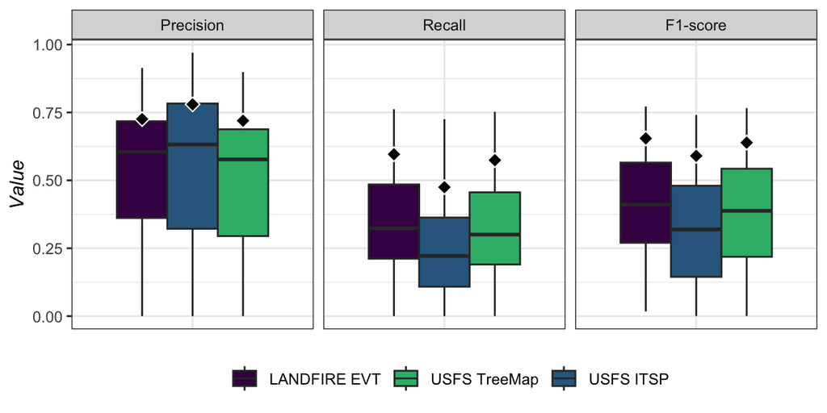

```r
flabs <- c(precision = "Precision", recall = "Recall", f1 = "F1-score")

# Reshape the agreement table for plotting facet wrap

# Southern Rockies (by block)
aggr.sr.m <- reshape2::melt(
  aggr.sr, id.vars = c("blocksize", "source", "region", "block"),
  measure.vars = c("precision", "recall", "f1"), variable.name = "statistic"
) %>%
  na.omit() %>%
  filter(blocksize == 1,
         block %in% blocks_aspen$id)

# White River NF
aggr.wr.m <- reshape2::melt(
  aggr.wr, id.vars = c("blocksize", "source", "region"),
  measure.vars = c("precision", "recall", "f1"), variable.name = "statistic"
) %>%
  na.omit() %>%
  filter(blocksize == 1)

# Facet wrap plot of the statistics by block group

f7 <- ggplot(data=aggr.sr.m, aes(x=factor(blocksize), y=value, fill=factor(source))) +
  geom_boxplot(position = position_dodge()) +
  scale_fill_viridis_d(labels=c("LANDFIRE EVT","USFS TreeMap","USFS ITSP"), name="",
                       breaks=c("LANDFIRE EVT", "USFS TreeMap", "USFS ITSP")) +
  facet_wrap(~statistic, labeller = labeller(statistic = flabs)) +
  theme_bw(11) +
  theme(legend.position = "bottom",
        legend.box = "vertical",
        legend.justification = c(0.5,0.5), # Left-aligns the legends
        legend.spacing.y = unit(-5, "pt"), # Adjusts the gap between the legends
        # legend.text = ggtext::element_markdown(halign = 0), # This aligns each individual legend's text to the left
        axis.title.x=element_blank(),  # Remove x axis title
        axis.text.x=element_blank(),   # Remove x axis text
        axis.ticks.x=element_blank(),  # Remove x axis ticks
        axis.title = element_text(size=11,face="italic")) +
        # text = element_text(family = "Times New Roman")) +
  labs(x="Blocksize", y="Value")

# Add the WRNF statistics
f7 <- f7 +
  geom_point(data=aggr.wr.m, aes(x=factor(blocksize), y=value, group=factor(source)),
             position=position_dodge(0.75), shape=18, size=4, color="white") +
  # Then add the actual point in black
  geom_point(data=aggr.wr.m, aes(x=factor(blocksize), y=value, group=factor(source)),
             position=position_dodge(0.75), shape=18, size=3, color="black") +
  scale_shape_manual(name="Subregion", values=c("White River NF" = 8)) +
  guides(
    fill=guide_legend(override.aes=list(shape=NA)), # No shape in the fill legend
    shape=guide_legend(title=" ", override.aes=list(color="black")) # Shape legend for Subregion
  )
f7
```

```r
# Save out
ggsave(f7, file = "../../figures/Figure7_Agreement_Box.png",
       dpi = 300, bg="white") # adjust dpi accordingly
```

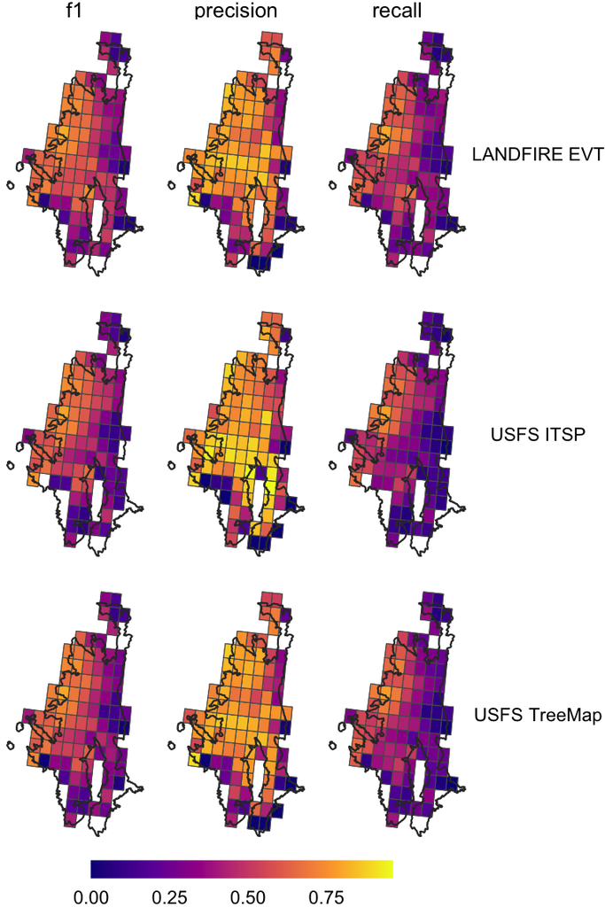

```r
# Add a spatial map of statistics by blocks
blocks_ <- blocks %>%
  mutate(id = as.numeric(id)-1) %>%
  rename(block = id) %>%
  left_join(aggr.sr, by="block") %>%
  pivot_longer(cols = c(precision, recall, f1), names_to = "statistic", values_to = "value") %>%
  na.omit()

f7b <- ggplot(data = blocks_) +
  geom_sf(aes(fill = value)) +
  geom_sf(data=srme, fill=NA, color="grey20", linewidth=0.4) +
  facet_grid(source ~ statistic) +
  scale_fill_viridis_c(option = "C") + # Use a continuous color scale
  theme_void() +
  theme(
    strip.text.x = element_text(size = 10),
    legend.position = "bottom"
  ) +
  guides(fill = guide_colourbar(direction = "horizontal", barwidth = 10, barheight = 0.60,
                                ticks=F, title.position = "left"),
         label.theme = element_text(angle = 0, size = 9)) +
  labs(fill="")
f7b
```

```r
# Save out
ggsave(f7b, file = "../../figures/Figure7_Agreement_Maps.png",
       dpi = 300, bg="white") # adjust dpi accordingly
```

Clean up!

```r
rm(f7b,f7,blocks_,blocks_aspen)
gc()
```

```
           used  (Mb) gc trigger  (Mb) limit (Mb) max used  (Mb)
Ncells  3679957 196.6    6065524 324.0         NA  6065524 324.0
Vcells 42389268 323.5   72676139 554.5      16384 72676139 554.5
```

## Figure 8: Landscape Patch Dynamics

```r
class.sr_ <- class.sr %>%
  mutate(source = if_else(source=="lc16_evt_200_bin_srme_10m", "LANDFIRE EVT", source),
         source = if_else(source=="s2aspen_prob_10m_binOpt_srme", "Sentinel-based Map", source),
         source = if_else(source=="usfs_itsp_aspen_ba_gt10_srme_10m", "USFS ITSP", source),
         source = if_else(source=="usfs_treemap16_balive_int_bin_srme_10m", "USFS TreeMap", source))
patch.sr_ <- patch.sr %>%
  mutate(source = if_else(source=="lc16_evt_200_bin_srme_10m", "LANDFIRE EVT", source),
         source = if_else(source=="s2aspen_prob_10m_binOpt_srme", "Sentinel-based Map", source),
         source = if_else(source=="usfs_itsp_aspen_ba_gt10_srme_10m", "USFS ITSP", source),
         source = if_else(source=="usfs_treemap16_balive_int_bin_srme_10m", "USFS TreeMap", source),
         area_qt = factor(ntile(area, 4), labels = c("Q1", "Q2", "Q3", "Q4")))
glimpse(patch.sr_)
```

```
Rows: 4,023,649
Columns: 9
$ ...1                 <dbl> 0, 1, 2, 3, 4, 5, 6, 7, 8, 9, 10, 11, 12, 13, 14, 15, 16, 17, 18, 19, 20, 21, 22, 23, 24, 25, 26, 27, 28, 29, 30, 31, 32, 33, 34, 35, …
$ area                 <dbl> 0.27, 0.18, 0.18, 0.18, 0.18, 0.09, 0.09, 0.09, 0.36, 0.27, 0.09, 0.18, 0.36, 0.18, 0.45, 2.07, 0.27, 0.18, 0.27, 0.18, 0.18, 0.09, 0.…
$ perimeter            <dbl> 240, 240, 240, 240, 240, 120, 120, 120, 360, 240, 120, 180, 360, 180, 360, 1440, 360, 180, 300, 180, 240, 120, 180, 120, 240, 360, 240…
$ perimeter_area_ratio <dbl> 888.8889, 1333.3333, 1333.3333, 1333.3333, 1333.3333, 1333.3333, 1333.3333, 1333.3333, 1000.0000, 888.8889, 1333.3333, 1000.0000, 1000…
$ shape_index          <dbl> 1.090909, 1.333333, 1.333333, 1.333333, 1.333333, 1.000000, 1.000000, 1.000000, 1.500000, 1.090909, 1.000000, 1.000000, 1.500000, 1.00…
$ region               <chr> "srme", "srme", "srme", "srme", "srme", "srme", "srme", "srme", "srme", "srme", "srme", "srme", "srme", "srme", "srme", "srme", "srme"…
$ source               <chr> "LANDFIRE EVT", "LANDFIRE EVT", "LANDFIRE EVT", "LANDFIRE EVT", "LANDFIRE EVT", "LANDFIRE EVT", "LANDFIRE EVT", "LANDFIRE EVT", "LANDF…
$ block_id             <dbl> 4, 4, 4, 4, 4, 4, 4, 4, 4, 4, 4, 4, 4, 4, 4, 4, 4, 4, 4, 4, 4, 4, 4, 4, 4, 4, 4, 4, 4, 4, 4, 4, 4, 4, 4, 4, 4, 4, 4, 4, 4, 4, 4, 4, 4,…
$ area_qt              <fct> Q3, Q3, Q3, Q3, Q3, Q2, Q2, Q2, Q4, Q3, Q2, Q3, Q4, Q3, Q4, Q4, Q3, Q3, Q3, Q3, Q3, Q2, Q3, Q2, Q3, Q4, Q3, Q4, Q2, Q2, Q3, Q3, Q2, Q4…
```

```r
glimpse(class.sr_)
```

```
Rows: 339
Columns: 8
$ ...1       <dbl> 0, 0, 0, 0, 0, 0, 0, 0, 0, 0, 0, 0, 0, 0, 0, 0, 0, 0, 0, 0, 0, 0, 0, 0, 0, 0, 0, 0, 0, 0, 0, 0, 0, 0, 0, 0, 0, 0, 0, 0, 0, 0, 0, 0, 0, 0, 0, 0, …
$ total_area <dbl> 1663.05, 1512.79, 2880.09, 1891.05, 7887.67, 12885.39, 11173.34, 9641.01, 11779.70, 7447.66, 9000.44, 2711.00, 3606.04, 2085.79, 1209.68, 6456.9…
$ prop_area  <dbl> 4.400219, 3.822703, 7.054768, 4.771215, 17.424149, 24.233280, 21.774401, 19.439621, 22.823152, 15.820654, 18.650975, 6.490377, 8.490949, 5.11635…
$ n_patch    <dbl> 2729, 2093, 4281, 2614, 9527, 11541, 11707, 8969, 10877, 7553, 15565, 6617, 6633, 4600, 3055, 5846, 3477, 4062, 10285, 11614, 7336, 8824, 6077, …
$ patch_den  <dbl> 7.220587, 5.288849, 10.486291, 6.595254, 21.045488, 21.704914, 22.814388, 18.084616, 21.074172, 16.044422, 32.254248, 15.841691, 15.618370, 11.2…
$ region     <chr> "srme", "srme", "srme", "srme", "srme", "srme", "srme", "srme", "srme", "srme", "srme", "srme", "srme", "srme", "srme", "srme", "srme", "srme", …
$ source     <chr> "LANDFIRE EVT", "LANDFIRE EVT", "LANDFIRE EVT", "LANDFIRE EVT", "LANDFIRE EVT", "LANDFIRE EVT", "LANDFIRE EVT", "LANDFIRE EVT", "LANDFIRE EVT", …
$ block_id   <dbl> 4, 8, 9, 10, 12, 20, 21, 22, 23, 24, 26, 27, 28, 29, 30, 37, 38, 42, 43, 45, 46, 47, 48, 49, 51, 55, 56, 57, 58, 59, 60, 61, 62, 63, 64, 65, 66,…
```

```r
class.wr_ <- class.wr %>%
  mutate(region = "wrnf") %>%
  mutate(source = if_else(source=="lc16_evt_200_bin_wrnf_10m", "LANDFIRE EVT", source),
         source = if_else(source=="s2aspen_prob_10m_binOpt_wrnf", "Sentinel-based Map", source),
         source = if_else(source=="usfs_itsp_aspen_ba_gt10_wrnf_10m", "USFS ITSP", source),
         source = if_else(source=="usfs_treemap16_balive_int_bin_wrnf_10m", "USFS TreeMap", source))
patch.wr_ <- patch.wr %>%
  mutate(region = "wrnf") %>%
  mutate(source = if_else(source=="lc16_evt_200_bin_wrnf_10m", "LANDFIRE EVT", source),
         source = if_else(source=="s2aspen_prob_10m_binOpt_wrnf", "Sentinel-based Map", source),
         source = if_else(source=="usfs_itsp_aspen_ba_gt10_wrnf_10m", "USFS ITSP", source),
         source = if_else(source=="usfs_treemap16_balive_int_bin_wrnf_10m", "USFS TreeMap", source),
         area_qt = factor(ntile(area, 4), labels = c("Q1", "Q2", "Q3", "Q4")))
rm(patch.sr,class.sr,patch.wr,class.wr)
```

Get some summary statistics:

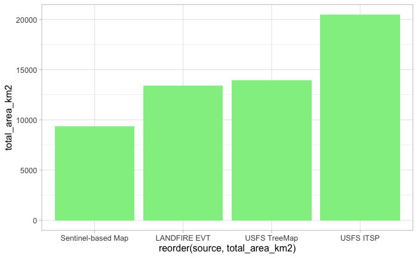

```r
class.sr_ %>%
  group_by(source) %>%
  summarize(
    total_area_km2 = sum(total_area) * 0.01
  ) %>%
  ggplot(aes(x=reorder(source, total_area_km2), y=total_area_km2)) +
  geom_bar(stat="identity", fill="light green") +
  theme_light(12)
```

```r
df1 <- class.sr_ %>%
  group_by(source) %>%
  summarize(
    total_area_km2 = sum(total_area) * 0.01,
    n_patch_total = sum(n_patch),
    patch_density_mn = mean(patch_den)
  )

df2 <- patch.sr_ %>%
  group_by(source) %>%
  summarize(
    patch_size_mn = mean(area),
    per_ar_r_mn = mean(perimeter_area_ratio)
  )

df <- left_join(df1,df2,by="source")
head(df)
```

| source | total_area_km2 | n_patch_total | patch_density_mn | patch_size_mn | per_ar_r_mn |
| --- | --- | --- | --- | --- | --- |
| LANDFIRE EVT | 13441.591 | 728370 | 14.217555 | 1.8454344 | 1060.9830 |
| Sentinel-based Map | 9384.414 | 1760386 | 35.725083 | 0.5330884 | 2745.5691 |
| USFS ITSP | 20477.692 | 266762 | 4.823169 | 7.6763901 | 941.7452 |
| USFS TreeMap | 13931.852 | 1268131 | 24.815014 | 1.0986130 | 1145.8826 |

```r
rm(df1,df2)

# Make a tidy table
# Set font name for table
fontname <- "Times New Roman"
# Clean up extra rows and digits
cleaned <- df %>%
 mutate_if(is.double, ~ round(., digits = 2)) %>%
 # Sort from fastest to slowest
 arrange(total_area_km2)
# Fix names and add units
names(cleaned) <- c("Data Source","Total Area (Km2)","Number of Patches","Patch Density",
                    "Average Patch Size (ha)","Average Perimeter/Area Ratio")
# Create the flextable
ft <- flextable::flextable(cleaned) %>%
  flextable::font(fontname = fontname, part = "all") %>%
  flextable::autofit() %>%
  flextable::fit_to_width(7.5)
ft
```

| Data Source | Total Area (Km2) | Number of Patches | Patch Density | Average Patch Size (ha) | Average Perimeter/Area Ratio |
| --- | --- | --- | --- | --- | --- |
| Sentinel-based Map | 9,384.41 | 1,760,386 | 35.73 | 0.53 | 2,745.57 |
| LANDFIRE EVT | 13,441.59 | 728,370 | 14.22 | 1.85 | 1,060.98 |
| USFS TreeMap | 13,931.85 | 1,268,131 | 24.82 | 1.10 | 1,145.88 |
| USFS ITSP | 20,477.69 | 266,762 | 4.82 | 7.68 | 941.75 |

```r
print(ft, preview = "docx")
```

```r
# Combine the White River NF and SRME to plot patch statistics
df <- bind_rows(patch.sr_,patch.wr_)
# Plot facet wrap of patch size
df <- df %>%
  group_by(source,region) %>%
  summarize(
    patch_size = mean(area),
    per_ar_r = mean(perimeter_area_ratio)
  )
glimpse(df)
```

```
Rows: 8
Columns: 4
Groups: source [4]
$ source     <chr> "LANDFIRE EVT", "LANDFIRE EVT", "Sentinel-based Map", "Sentinel-based Map", "USFS ITSP", "USFS ITSP", "USFS TreeMap", "USFS TreeMap"
$ region     <chr> "srme", "wrnf", "srme", "wrnf", "srme", "wrnf", "srme", "wrnf"
$ patch_size <dbl> 1.8454344, 3.4151061, 0.5330884, 0.7358793, 7.6763901, 14.8811627, 1.0986130, 2.2167857
$ per_ar_r   <dbl> 1060.9830, 1046.2439, 2745.5691, 2872.1164, 941.7452, 944.5034, 1145.8826, 1125.3520
```

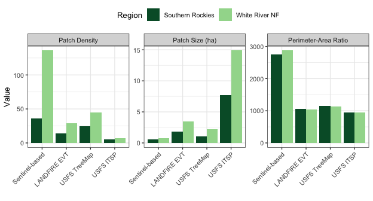

```r
# Get the class metrics in the same format
df2 <- bind_rows(class.sr_,class.wr_) %>%
  group_by(source,region) %>%
  summarize(
    patch_den = mean(patch_den)
  )
df_ <- left_join(df,df2,by=c("region","source"))

# Pivot longer

metric_labels <- c(patch_size = "Patch Size (ha)",
                   per_ar_r = "Perimeter-Area Ratio",
                   patch_den = "Patch Density")

df.long <- df_ %>%
  pivot_longer(cols = c(contains("_")),
               names_to = "metric",
               values_to = "value") %>%
  mutate(region = if_else(region=="srme","Southern Rockies","White River NF"),
         source = if_else(source=="Sentinel-based Map","Sentinel-based",source),
         source = factor(source, levels = rev(levels(reorder(source, value)))))

df.long$source <- factor(df.long$source,levels=c('Sentinel-based', 'LANDFIRE EVT', 'USFS TreeMap', 'USFS ITSP'))

cols <- c("#005a32","#a1d99b")

# Grouped bar chart
f7 <- ggplot(data=df.long, aes(x=source, y=value, fill=factor(region))) +
  geom_bar(stat="identity", position=position_dodge()) +
  scale_fill_manual(values=cols) +
  facet_wrap(~metric, scales = "free_y", labeller = labeller(metric = metric_labels)) + # Faceting by summary variable
  labs(x="", y="Value", fill="Region") + # Adding labels
  theme_bw(10) +
  theme(legend.position = "top") +
  theme(axis.text.x = element_text(angle=45, hjust=1)) # Improving readability of x-axis labels
f7
```

```r
ggsave(f7, file = "../../figures/Figure7_Landscape_Summaries.png", dpi=300)
```

Calculate the difference in class statistics between the different sources:

```r
# Calculate the grouped statistics for the SR
df <- bind_rows(class.sr_,class.wr_) %>%
  group_by(source,region) %>%
  summarize(
    total_area_km2 = sum(total_area) * 0.01,
    total_n_patch = sum(n_patch)
  ) %>%
  ungroup()
head(df, 8)
```

| source | region | total_area_km2 | total_n_patch |
| --- | --- | --- | --- |
| LANDFIRE EVT | srme | 13441.591 | 728370 |
| LANDFIRE EVT | wrnf | 2017.269 | 59069 |
| Sentinel-based Map | srme | 9384.414 | 1760386 |
| Sentinel-based Map | wrnf | 1657.340 | 225219 |
| USFS ITSP | srme | 20477.692 | 266762 |
| USFS ITSP | wrnf | 2722.211 | 18293 |
| USFS TreeMap | srme | 13931.852 | 1268131 |
| USFS TreeMap | wrnf | 2077.084 | 93698 |

```r
# Step 1: Filter out Sentinel-based map values
sentinel_df <- df %>%
  filter(source == "Sentinel-based Map") %>%
  rename(sentinel_area_km2 = total_area_km2,
         sentinel_n_patch = total_n_patch) %>%
  select(region,sentinel_area_km2,sentinel_n_patch)

# Step 2: Join this with the original dataframe on region
df <- df %>%
  left_join(sentinel_df, by = "region")

# Step 3: Calculate the percentage difference
# Ensure that you're not comparing Sentinel-based map values with itself
df <- df %>%
  filter(source != "Sentinel-based Map") %>%
  mutate(area_diff = (total_area_km2 - sentinel_area_km2) / sentinel_area_km2 * 100,
         patch_diff = (total_n_patch - sentinel_n_patch) / sentinel_n_patch * 100)
head(df)
```

| source | region | total_area_km2 | total_n_patch | sentinel_area_km2 | sentinel_n_patch | area_diff | patch_diff |
| --- | --- | --- | --- | --- | --- | --- | --- |
| LANDFIRE EVT | srme | 13441.591 | 728370 | 9384.414 | 1760386 | 43.23314 | -58.62442 |
| LANDFIRE EVT | wrnf | 2017.269 | 59069 | 1657.340 | 225219 | 21.71728 | -73.77264 |
| USFS ITSP | srme | 20477.692 | 266762 | 9384.414 | 1760386 | 118.20960 | -84.84639 |
| USFS ITSP | wrnf | 2722.211 | 18293 | 1657.340 | 225219 | 64.25183 | -91.87768 |
| USFS TreeMap | srme | 13931.852 | 1268131 | 9384.414 | 1760386 | 48.45735 | -27.96290 |
| USFS TreeMap | wrnf | 2077.084 | 93698 | 1657.340 | 225219 | 25.32637 | -58.39694 |

```r
NA
```

Calculate the difference in patch statistics between the different sources:

```r
# Calculate the grouped statistics for the SR
df <- bind_rows(patch.sr_,patch.wr_) %>%
  group_by(source,region) %>%
  summarize(
    patch_size_mn = mean(area),
    patch_size_sd = sd(area)
  ) %>%
  ungroup()
head(df, 8)
```

| source | region | patch_size_mn | patch_size_sd |
| --- | --- | --- | --- |
| LANDFIRE EVT | srme | 1.8454344 | 82.34567 |
| LANDFIRE EVT | wrnf | 3.4151061 | 115.15291 |
| Sentinel-based Map | srme | 0.5330884 | 23.24305 |
| Sentinel-based Map | wrnf | 0.7358793 | 22.85599 |
| USFS ITSP | srme | 7.6763901 | 298.83631 |
| USFS ITSP | wrnf | 14.8811627 | 558.04328 |
| USFS TreeMap | srme | 1.0986130 | 60.86914 |
| USFS TreeMap | wrnf | 2.2167857 | 93.04041 |

```r
# Step 1: Filter out Sentinel-based map values
sentinel_df <- df %>%
  filter(source == "Sentinel-based Map") %>%
  rename(sentinel_patch_size_mn = patch_size_mn) %>%
  select(region,sentinel_patch_size_mn)

# Step 2: Join this with the original dataframe on region
df <- df %>%
  left_join(sentinel_df, by = "region")

# Step 3: Calculate the percentage difference
# Ensure that you're not comparing Sentinel-based map values with itself
df <- df %>%
  filter(source != "Sentinel-based Map") %>%
  mutate(percentage_difference = (patch_size_mn - sentinel_patch_size_mn) / sentinel_patch_size_mn * 100)
head(df)
```

| source | region | patch_size_mn | patch_size_sd | sentinel_patch_size_mn | percentage_difference |
| --- | --- | --- | --- | --- | --- |
| LANDFIRE EVT | srme | 1.845434 | 82.34567 | 0.5330884 | 246.1779 |
| LANDFIRE EVT | wrnf | 3.415106 | 115.15291 | 0.7358793 | 364.0851 |
| USFS ITSP | srme | 7.676390 | 298.83631 | 0.5330884 | 1339.9844 |
| USFS ITSP | wrnf | 14.881163 | 558.04328 | 0.7358793 | 1922.2289 |
| USFS TreeMap | srme | 1.098613 | 60.86914 | 0.5330884 | 106.0846 |
| USFS TreeMap | wrnf | 2.216786 | 93.04041 | 0.7358793 | 201.2431 |

Calculate some grouped statistics (to compare with the class metrics results)

```r
# Also create a grouped summary
(patch.summary <- patch_metrics %>%
  group_by(source,region) %>%
  summarize(area_md = median(area), # convert to hectares
            area_mn = mean(area),
            area_sum = sum(area),
            perim_md = median(perimeter),
            perim_mn = mean(perimeter),
            par_md = median(perimeter_area_ratio),
            par_mn = mean(perimeter_area_ratio),
            si_md = median(shape_index),
            si_mn = mean(shape_index)) %>%
  ungroup())

(patch.long <- patch.summary %>%
  pivot_longer(cols = c(contains("_")),
               names_to = "metric",
               values_to = "value"))

patch.long$source <- factor(patch.long$source,levels=c('Aspen10m', 'Aspen30m', 'LFEVT', 'TreeMap', 'ITSP'))

(ggplot(data = patch.long, aes(x=source, y=value, fill=region)) +
    geom_bar(stat="identity", position="dodge", width=0.7) +
    facet_wrap(~metric, scales="free") +
    theme_minimal(14) +
    theme(axis.text.x = element_text(angle = 45, hjust = 1),
    text = element_text(family = "Arial")))

(f8s <- ggplot(data = patch.long, aes(x=source, y=value, fill=region)) +
    geom_bar(stat="identity", position="dodge", width=0.7) +
    theme_minimal(14) +
    theme(axis.text.x = element_text(angle = 45, hjust = 1),
    text = element_text(family = "Arial")))
```

Grab some summary statistics on the patch dynamics:

```r
a <- patch.long %>% filter(region=="SRME",metric=="area_mn",source=="Aspen10m")
b <- patch.long %>% filter(region=="SRME",metric=="area_mn",source=="LFEVT")

print("Difference in mean patch size for the SRME: ")
((b$value-a$value)/b$value)*100

a <- patch.long %>% filter(region=="WRNF",metric=="area_mn",source=="Aspen10m")
b <- patch.long %>% filter(region=="WRNF",metric=="area_mn",source=="LFEVT")

print("Difference in mean patch size for the WRNF: ")
((b$value-a$value)/b$value)*100

print("~~~~~~~~~~~~~~~~")

print("Difference in mean patch size for the SRME: ")
((b$value-a$value)/b$value)*100

(c <- patch.long %>% filter(metric=="area_md",source=="Aspen10m"))
(d <- patch.long %>% filter(metric=="area_md",source=="LFEVT"))

print("Mean and median patch sizes: ")
paste0("Aspen10m mean: ",a$value)
paste0("LFEVT mean: ",b$value)
paste0("Aspen10m median: ",c$value)
paste0("LFEVT mean: ",d$value)



print("Difference in median area: ")
((d$value-c$value)/d$value)*100

print("Mean Perimeter area ratio: ")
(a <- patch.long %>% filter(metric=="par_mn",source=="Aspen10m"))
(b <- patch.long %>% filter(metric=="par_mn",source=="LFEVT"))

print("Difference in PAR: ")
((b$value-a$value)/b$value)*100

rm(a,b,c,d)
```

Boxplot as facet wrap for patch metrics:

```r
brewer.pal(n=5,"Set1")

cols <- c("#005a32","#a1d99b")

(df <- patch_metrics %>%
  # mutate(area_ha = area*100) %>%
  select(-c(X,index,shape_index)) %>%
  pivot_longer(contains(c("area","perimeter_area_ratio"))) %>%
  arrange(source, desc(value)) %>%
  mutate(name = as.character(name),
         name = recode(name,
                       "area" = "Patch Size (ha)",
                       "perimeter_area_ratio" = "Perimeter/Area Ratio")))

df$source <- factor(df$source,
                    levels=c('Aspen10m', 'Aspen30m', 'LFEVT', 'TreeMap', 'ITSP'))

(f8a <- ggplot(data=df, aes(y = value, x = factor(source), fill = factor(region))) +
  geom_boxplot(outlier.size = 0.2) +
  scale_y_continuous(trans="log10",labels=label_number_si(accuracy = 1)) +
  scale_fill_manual(values=cols) +
  facet_wrap(~name, scales = "free_y", nrow=1) +
  labs(x="\nData Source",y="Value",title="Patch Metrics", fill="Region: ") +
  theme_light(12) +
  theme(axis.text.x = element_text(angle = 45, hjust = 1, size=11),
        axis.text.y = element_text(angle = 0, vjust=0.1, size=11),
        axis.title.y = element_text(size=12, face="italic", vjust=1),
        axis.title.x = element_text(size=12, face="italic", vjust=-1),
        plot.margin = unit(c(0.5,0.5,0.5,0.5),"cm"),
        legend.position="top",
        legend.spacing.x = unit(0.5,"cm"),
        text = element_text(family = "Arial")))

ggsave(f8a, file = "../../figures/Figure8A_patch_metrics.png", dpi = 300) # adjust dpi accordingly
```

Plot class metrics as facet wrap:

```r
# Calculate area in square meters
srme_area_km2 <- st_area(srme) / 1e6
wrnf_area_km2 <- st_area(wrnf) / 1e6

(df <- class_metrics %>%
  mutate(total_area = total_area*0.01,
         prop_area = if_else(region=="SRME", as.double((total_area/srme_area_km2*100)), 0.0),
         prop_area = if_else(region=="WRNF", as.double((total_area/wrnf_area_km2*100)), prop_area)) %>%
  select(-c(X)) %>%
  pivot_longer(cols = c(contains("_")),
               names_to = "metric",
               values_to = "value") %>%
  mutate(metric = as.character(metric),
         metric = recode(metric,
                         "n_patch" = "Number of Patches",
                         "patch_den" = "Patch Density",
                         "total_area" = "Total area (km2)",
                         "prop_area" = "Proportion of Area")))

df$source <- factor(df$source, levels=c('Aspen10m', 'Aspen30m', 'LFEVT', 'TreeMap', 'ITSP'))
head(df)

(f8b <- ggplot(data=df, aes(y=value, x=factor(source), fill=factor(region))) +
  geom_bar(stat="identity", position="dodge", width=0.7) +
  scale_y_continuous(labels=scales::label_number_si(accuracy = 1)) +
  scale_fill_manual(values=cols) +
  labs(x="", y="Value", title="Landscape Metrics", fill="Region: ") +
  theme(axis.title.x = NULL) +
  facet_wrap(~metric, scales = "free_y") +
  theme_light(12) +
  theme(axis.text.x = element_text(angle = 45, hjust = 1, size=11),
        axis.text.y = element_text(angle = 0, vjust=0.1, size=11),
        axis.title.y = element_text(size=12, face="italic", vjust=0.5),
        axis.title.x = element_text(size=12, face="italic", vjust=-0.5),
        plot.margin = unit(c(0.5,0.5,0.5,0.5),"cm"),
        legend.position = "top",
        legend.spacing.x = unit(0.5,"cm"),
        text = element_text(family = "Arial")))

ggsave(f8b, file = "../../figures/Figure8B_landscape_metrics.png", dpi = 300) # adjust dpi accordingly
```

```r
(arr <- ggarrange(f8b,f8a,nrow=2,ncol=1,labels=c("A","B"), common.legend = T))
ggsave(arr, file="../../figures/Figure8_Landscape_Patch_Metrics.png", dpi=300)
```

```r
print("% Difference in number of patches across the Southern Rockies: ")
a <- df %>% filter(region=="SRME",metric=="Number of Patches",source=="Aspen10m")
b <- df %>% filter(region=="SRME",metric=="Number of Patches",source=="LFEVT")
((b$value-a$value)/b$value)*100

print("% Difference in number of patches across the White River NF: ")
a <- df %>% filter(region=="WRNF",metric=="Number of Patches",source=="Aspen10m")
b <- df %>% filter(region=="WRNF",metric=="Number of Patches",source=="LFEVT")
((b$value-a$value)/b$value)*100

print("~~~~~~~~~~~~~")

print("~~~~~~~~~~~~~")

print("% Difference in patch density: ")
a <- df %>% filter(metric=="Patch Density",source=="Aspen10m")
b <- df %>% filter(metric=="Patch Density",source=="LFEVT")
((b$value-a$value)/b$value)*100

print("% Difference in total area:")
a <- df %>% filter(metric=="Total area (km2)",source=="Aspen10m")
aa <- df %>% filter(metric=="Total area (km2)",source=="Aspen30m")
b <- df %>% filter(metric=="Total area (km2)",source=="LFEVT")
((b$value-a$value)/b$value)*100
((b$value-aa$value)/b$value)*100

rm(a,aa,b)
```

# Supplemental

Load the spatial block grid and phenology time-series summaries by spatial block for the Southern Rockies. Join the phenology summaries to their geometries.

```r
# Load the grids, keep the elevation attribute and TreeMap sum (aspen area)
grid <- st_read('../../data/spatial/mod/boundaries/spatial_block_grid_50km2.gpkg',
                quiet=T) %>%
  select(grid_id,elevation_mn,treemap_sum,treemap_pct)

# Load the phenology by spatial block grid
phenology <- read_csv('../../data/tabular/mod/phenology/viirs_phenology_by_grid_in_aspen.csv',
                      show_col_types = FALSE) %>%
  rename(fid = `system:index`) %>%
  mutate(grid_id = str_sub(fid, -7),
         year = as.integer(str_sub(fid, 1, 4))) %>%
  select(-c(fid,label,count,.geo)) %>%
  # Create DOY versions of the phenology metrics for plotting and statistical analysis
  mutate(
    season_length = Growing_Season_Length_1_median,
    doy_midgreenup = yday(Date_Mid_Greenup_Phase_1_median),
    doy_midsenescence = yday(Date_Mid_Senescence_Phase_1_median),
    doy_green_dec = yday(Onset_Greenness_Decrease_1_median),
    doy_green_inc = yday(Onset_Greenness_Increase_1_median),
    doy_green_max = yday(Onset_Greenness_Maximum_1_median),
    doy_green_min = yday(Onset_Greenness_Minimum_1_median)
  ) %>%
  left_join(grid%>%as_tibble(), by="grid_id") %>%
  select(grid_id,year,elevation_mn,season_length,doy_midgreenup,doy_midsenescence,
         doy_green_dec,doy_green_inc,doy_green_max,doy_green_min)

glimpse(phenology)
```

Spatial maps of the key phenology metrics.

```r
# Calculate the median phenology metrics
phenology.md <- phenology %>%
  group_by(grid_id) %>%
  summarise(across(starts_with("doy"), median, na.rm=T))

# Join to the spatial data and pivot longer
grid.l <- grid %>%
  left_join(phenology.md, by="grid_id") %>%
  pivot_longer(cols = starts_with("doy"), names_to = "metric", values_to = "value") %>%
  filter(treemap_pct > 0.05) # Keep only blocks with some aspen cover

ordered_metrics <- c(
  "doy_green_inc","doy_midgreenup","doy_green_max",
  "doy_green_dec","doy_midsenescence","doy_green_min")

# Tidy the names for plotting
metric_names <- c(
  doy_green_inc = "Onset Greenness Increase",
  doy_midgreenup = "Mid Greenup Phase",
  doy_green_max = "Onset Greenness Maximum",
  doy_green_dec = "Onset Greenness Decrease",
  doy_midsenescence = "Mid Senescence Phase",
  doy_green_min = "Onset Greenness Minimum"
)

# Fix the factor levels and labels
grid.l$metric <- factor(grid.l$metric, levels = ordered_metrics, labels = metric_names)

head(grid.l)
```

```r
metrics <- unique(grid.l$metric)

plots <- list()

for (m in metrics){
  # Filter for the metric
  gdf <- grid.l %>% filter(metric == m)

  # Map
  p <- ggplot() +
    geom_sf(data=grid, fill=NA) +
    geom_sf(data=gdf, aes(fill=value)) +
    scale_fill_continuous(low = "lightgreen", high = "darkgreen",
                          labels = function(x) format(as.Date(as.numeric(x), origin="1970-01-01"), "%b %d")) +
    geom_sf(data=srme,fill=NA,color="black",size=2.5) +
    labs(fill="", title=m) +
    theme_void(12) +
    theme(legend.position = "right",
          legend.text = element_text(angle = 0, size=9),   # Ensure labels are not rotated
          plot.title = element_text(hjust = 0.5, size=10),
          plot.margin = ggplot2::margin(0.1, 5, 0.1, 5, "mm")
    ) +
    guides(fill = guide_colourbar(
      barwidth = 0.5,
      barheight = 6,
      ticks = FALSE,
      label.position = "right",
      label.theme = element_text(size = 8))
    )
  # Save the individual map
  ggsave(p, file=paste0("../../figures/FigureS1B_Phenology_by_Elevation",m,".png"), dpi=300)
  print(p)
  plots[[m]] <- p
}
```

Create a combined plot for four metrics.

```r
# Create one map with a scale bar and north arrow

arrow <- ggspatial::north_arrow_minimal(
  line_width = 1,
  line_col = "black",
  fill = "black",
  text_col = "black",
  text_family = "",
  text_face = NULL,
  text_size = 8
)

p1 <- plots[[1]] +
  ggspatial::annotation_scale(location = "bl", width_hint = 0.25, pad_x = unit(-0.01,"in"),
                              text_cex=0.6) +
  ggspatial::annotation_north_arrow(location = "bl", which_north = "true",
                                    pad_x = unit(0.1, "in"), pad_y = unit(0.3, "in"),
                                    height=unit(0.3,"in"), width=unit(0.3,"in"),
                                    style=arrow)


fs1a <- ggarrange(p1, plots[[3]], plots[[2]], plots[[6]],
                  ncol = 2, nrow = 2, widths=c(1,1,1,1), heights=c(1,1,1,1),
                  align = "hv", labels = c("A","B","C","D"))
fs1a
ggsave(fs1a, file="../../figures/FigureS1A_PhenologyMaps.png", dpi=300)

rm(p1)
```

Plot the relationship with elevation across metrics.

```r
metrics <- c("Mid Greenup Phase", "Onset Greenness Decrease", "Mid Senescence Phase", "Onset Greenness Minimum")

df <- grid.l %>% filter(metric %in% metrics)

# Individual plots
for (m in metrics){
  # Filter for the metric
  gdf <- grid.l %>% filter(metric == m)

  # Map
  p <- ggplot(data=gdf, aes(x=value,y=elevation_mn)) +
    geom_smooth(method="lm",colour="gray40", fill="gray70", size=0.5) +
    geom_point(size=0.4) +
    theme_bw(7) +
    theme(axis.text = element_blank(),
          axis.title = element_text(size=6),
          axis.ticks = element_blank()) +
    labs(x="Day of Year",y="Elevation")
  ggsave(p, file=paste0("../../figures/FigureS1B_Phenology_by_Elevation_",m,".png"), width=1.5, height=1.5)
  print(p)
}

# Facet plot
(fs1b <- ggplot(data=df, aes(x=value,y=elevation_mn)) +
  geom_smooth(method="lm",colour="gray40", fill="gray70", size=0.8) +
  geom_point(size=0.8) +
  facet_wrap(~metric, scales="free_x", nrow=2) +
  theme_minimal(12) +
  theme(plot.title = element_text(size=10),
        axis.text = element_text(size=8),
        axis.title = element_text(size=10),
        strip.text = element_text(size=8),
        panel.spacing = unit(2.5, "mm")) +
  labs(x="Day of Year",y="Elevation", tag="B"))

# Save out
ggsave(fs1b, file="../../figures/FigureS1B_Phenology_by_Elevation.png", dpi=300)

rm(metrics,df)
```

Merge the two plots.

```r
(fs1 <- ggarrange(fs1a, fs1b, nrow=2, ncol=1, align="v"))
ggsave(fs1, file="../../figures/FigureS1_Phenology.png", dpi=300)
```

```r
# Reshape from wide to long format
phenology.l <- phenology %>%
  pivot_longer(
    cols = c(doy_midgreenup,doy_midsenescence,doy_green_dec,
             doy_green_inc,doy_green_max,doy_green_min),
    names_to = "metric",
    values_to = "doy"
  )

ordered_metrics <- c(
  "doy_green_inc","doy_midgreenup","doy_green_max",
  "doy_green_dec","doy_midsenescence","doy_green_min")

metric_names <- c(
  doy_green_inc = "Onset Greenness Increase",
  doy_midgreenup = "Mid Greenup Phase",
  doy_green_max = "Onset Greenness Maximum",
  doy_green_dec = "Onset Greenness Decrease",
  doy_midsenescence = "Mid Senescence Phase",
  doy_green_min = "Onset Greenness Minimum"
)

phenology.l$metric <- factor(
  phenology.l$metric,
  levels = ordered_metrics,
  labels = metric_names
)

# Create the plot with facet_wrap
ggplot(phenology.l, aes(x=factor(year), y=doy)) +
  geom_boxplot() +
  facet_wrap(~ metric, scales = "fixed") +
  theme_minimal() +
  labs(title = "DOY Phenology Metrics (2013-2022)",
       x = "Year",
       y = "Day of Year",
       fill = "Year") +
  theme_light() +
  theme(axis.text.x = element_text(angle = 45, hjust = 1))

# Stacked box plots
ggplot(phenology.l, aes(x=factor(year), y=doy, fill=metric)) +
  geom_boxplot(width=1) +
  theme_minimal() +
  labs(x = "Year",
       y = "Day of Year",
       fill = "Metric") +
  theme_light() +
  theme(axis.text.x = element_text(angle = 45, hjust = 1),
        legend.position = "top")
```

Create a pretty table.

```r
library(flextable, quietly = T)

# Get the best F1 score for each model run
accmeas.best <- accmeas %>%
  mutate(model = as.factor(model)) %>%
  group_by(model) %>%
  top_n(1,f1) %>%
  ungroup() %>%
  mutate(model_iter = row_number()) %>%
  select(model,prSize,bgSize,tpr,precision,recall,f1,cutoff)

head(accmeas.best,10)

# Fix names and add units
names(accmeas.best) <- c("Model Seed",
                         "# of Presence",
                         "# of Background",
                         "True Positive Rate",
                         "Precision",
                         "Recall",
                         "F1-Score",
                         "Threshold")

# Set font name for table
fontname <- "Times New Roman"

# Create the flextable
(ft1 <- flextable(accmeas.best) %>%
 font(fontname = fontname, part = "all") %>%
 autofit() %>% fit_to_width(6.5))
print(ft1, preview = "docx")

# Write to a CSV
write_csv(accmeas.best, "../../figures/TableS1_Accuracy_MaxF1.csv")
```

Clean up!